# Latent Variable Models : applications and examples

```python
from jyquickhelper import add_notebook_menu
add_notebook_menu()
```

run previous cell, wait for 2 seconds

## Reminder & warm-up

An EM algorithm is an iterative optimization of the following variational lower bound $\mathcal{L}(\theta, q) = \int q(T) \log\frac{p(X, T|\theta)}{q(T)}dT$.

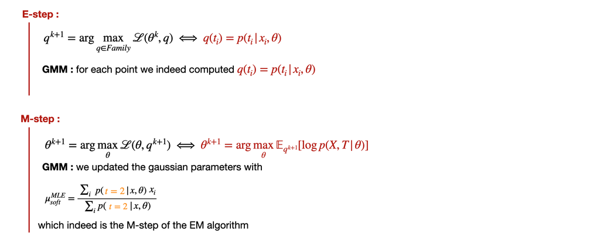

```python
from sklearn.datasets import load_breast_cancer
data = load_breast_cancer()
X = data["data"]
y = data["target"]
```

**Question 1 :** Give the shape of X and y.

```python
print("shape of X :", X.shape)
print("shape of y :", y.shape)
```

```
shape of X : (569, 30)
shape of y : (569,)
```

**Question 2 :** Plot the first two dimension of X and color the instances according to its class y

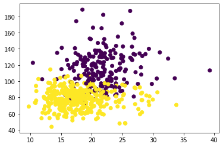

```python
import matplotlib.pyplot as plt

plt.scatter(X[:,1], X[:,2], c = y, cmap='viridis');
```

For the sake of the following section, let us discard completely the class y.

## 1. Clustering : a probabilistic point of view with k-means

We recall that k-means is a clustering algorithm which has the following pseudo-algorotihm :

**Input :** number of clusters $K$, dataset $X$

**Output :** the clusters

1. Randomly initialize the parameters $\theta = \{centroid_1, \dots, centroid_K\}$
2. Repeat until convergence :
   - For each instance $x$, compute the closest centroid : $$ k_i = \arg\min_{k} \lVert x_i - centroid_k \lVert^2 $$
   - Update the centroids : $$ centroid_k = \frac{\sum_{i:k_i=k} x_i}{|{i:k_i=k}|} $$

**Question 3 :** Define the function `kmeans_naive` and test it out on $X$ with $K=3$. Plot the first two dimensions of $X$ and color the instances according to its cluster

```python
from sklearn.metrics import pairwise_distances
import numpy as np
# you can use "pairwise_distances" for computing the closest centroid between X and the centroids

def kmeans_naive(K, X, max_iter = 10):
    ### CODE

    # step 1 : let's init theta randomly
    rand_indices = np.random.choice(X.shape[0], size = K)
    centroids = X[rand_indices]

    # step 2 : repeat until convergence
    for _ in range(max_iter):
        cluster_distance = pairwise_distances(X, centroids, metric = 'euclidean', force_all_finite = False)
        cluster_assignment = np.argmin(cluster_distance, axis = 1)

        for k in range(K):
            centroids[k,:] = np.nanmean(X[cluster_assignment == k], axis = 0)

    return cluster_assignment
```

```python
labels = kmeans_naive(3, X, 5)
```

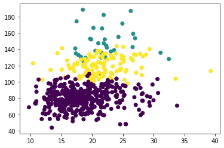

```python
plt.scatter(X[:,1], X[:,2], c = labels, cmap='viridis');
```

**Question 4 :** Define the function `GMM_hard` (p.24) which fit a Gaussian Mixture Model (with hard clustering). We assume two things here

- $\Sigma = I_d$ is **known** and is identical ;
- $\pi_k$ is known and is uniform.

```python
def GMM_hard(K, X, max_iter = 10):
    ### CODE

    # step 1 : let's init theta randomly
    rand_indices = np.random.choice(X.shape[0], size = K)
    centroids = X[rand_indices]

    # step 2 : repeat until convergence
    for _ in range(max_iter):
        cluster_distance = pairwise_distances(X, centroids, metric = 'euclidean', force_all_finite = False)
        cluster_assignment = np.argmin(cluster_distance, axis = 1)

        for k in range(K):
            centroids[k,:] = np.nanmean(X[cluster_assignment == k], axis = 0)

    return cluster_assignment
```

**Question 5 :** What do we see ?

If we choose :

- the covariances $\Sigma_k$ of the GMM be identitcal : $\Sigma_k = I_d$ and
- the weights $\pi_k$of the GMM to be unform : $\pi_k = \frac{1}{\text{number of gaussians}}$

Then we have k-means

**Question 5 :** Redefine `GMM_hard` but this time we assume that $\Sigma_k$ and $\pi_k$ are no longer known. Plot the results

```python
from scipy.stats import multivariate_normal
from scipy.special import softmax

def GMM_hard(K, X, max_iter = 10):
    """
    X has the standard shape : (n, d)
    """
    n, d = X.shape

    # Spliting the data in K sub-sets
    X_split = np.array_split(X, K)

    # step 1 : let's initialize pis, mus and Sigmas
    pis = np.ones(K)/K
    mus = np.array([np.nanmean(x, axis=0) for x in X_split])
    Sigmas = np.array([np.cov(x.T) for x in X_split])
    print("shape of pi", pis.shape)
    print("shape of mu", mus.shape)
    print("shape of sigma", Sigmas.shape)

    # step 2 : repeat until convergence
    for _ in range(max_iter):

        if np.sum(np.isnan(mus)):
            break

        # E-step : compute posteriors thx to parameters -------------------
        gamma = np.zeros((n, K)) # distribution q(T)

        for i in range(n):
            for k in range(K):
                rv = multivariate_normal(mus[k, :], Sigmas[k], allow_singular=True)
                gamma[i, k] = np.array(rv.pdf(X[i]) * pis[k])
            gamma[i, :] = softmax(gamma[i, :])

        # M-step : compute parameters thx to posteriors -------------------
        cluster_assignment = np.argmax(gamma, axis=1)

        for k in range(K):
            pis[k] = np.nanmean(gamma[:, k])
            mus[k,:] = np.nanmean(X[cluster_assignment==k], axis = 0)
            Sigmas[k] = np.cov(X[cluster_assignment==k].T)
        print(pis)

    return cluster_assignment
```

```python
labels = GMM_hard(3, X, 5)
```

```
shape of pi (3,)
shape of mu (3, 30)
shape of sigma (3, 30, 30)
[0.32480906 0.32538948 0.34980146]
[0.1458639  0.14586353 0.70827256]
[0.13555129 0.13555108 0.72889763]
[0.13413415 0.13413387 0.73173198]
[0.11652189 0.11652161 0.76695649]
```

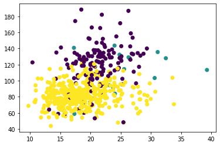

```python
plt.scatter(X[:,1], X[:,2], c = labels, cmap='viridis');
```

**[OPTIONAL] Question 6 :** Define `GMM_soft` which fit a GMM with soft clustering. Plot the results

```python
from scipy.stats import multivariate_normal

def GMM_soft(K, X, max_iter = 10):
    """
    X has the standard shape : (n, d)
    """
    n, d = X.shape

    # Spliting the data in K sub-sets
    X_split = np.array_split(X, K)

    # step 1 : let's initialize pis, mus and Sigmas
    pis = np.ones(K)/K
    mus = np.array([np.nanmean(x, axis=0) for x in X_split])
    Sigmas = np.array([np.cov(x.T) for x in X_split])
    print("shape of pi", pis.shape)
    print("shape of mu", mus.shape)
    print("shape of sigma", Sigmas.shape)

    # step 2 : repeat until convergence
    for _ in range(max_iter):

        if np.sum(np.isnan(mus)):
            break

        # E-step : compute posteriors thx to parameters -------------------
        gamma = np.zeros((n, K)) # distribution q(T)

        for i in range(n):
            for k in range(K):
                rv = multivariate_normal(mus[k, :], Sigmas[k], allow_singular=True)
                gamma[i, k] = np.array(rv.pdf(X[i]) * pis[k])
            gamma[i, :] = softmax(gamma[i, :])

        # M-step : compute parameters thx to posteriors -------------------
        for k in range(K):
            pis[k] = np.nanmean(gamma[:, k])
            mus[k,:] = np.average(X, weights=gamma[:, k], axis=0)
            Sigmas[k] = np.average(np.linalg.norm(X-mus[k], ord=2, axis=1), weights=gamma[:, k], axis=0)

        print(np.nanmean(gamma, axis=0))
    return np.argmax(gamma, axis=1)
```

```python
labels = GMM_soft(3, X, 5)
```

```
shape of pi (3,)
shape of mu (3, 30)
shape of sigma (3, 30, 30)
[0.32480906 0.32538948 0.34980146]
[0.33332578 0.33332628 0.33334794]
[0.33333333 0.33333333 0.33333335]
[0.33333333 0.33333333 0.33333333]
[0.33333333 0.33333333 0.33333333]
```

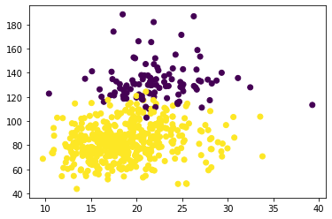

```python
plt.scatter(X[:,1], X[:,2], c = labels, cmap='viridis');
```

We can see that GMM with soft clustering is (visually) quite good ! Indeed, we seem to have the same distribution as the original labels.

## 2. Dimensionality reduction : a probabilistic point of view with PCA

PPCA is a dimensionality reduction technique that is often used when we have some missing values in the dataset. We assume that each latent variable is normally distributed : $$ t_i \sim \mathcal{N}(0, I_K) $$

The instance $x$ associated is generated by the following projection : $$ x_i | t_i \sim \mathcal{N}(W\cdot t_i + b, \Sigma) $$

**Question 7 :** The PPCA is a general form of PCA. Indeed, we can observe it in marginalizing the latent variable. Find out the distribution of each instance $x | \theta$ (you can use the wikipedia table for the normal conjugacy).

**Question 8 :** Compute the E-step of the PPCA

**Question 9 :** Compute the M-step of the PPCA

**Question 10 :** Do a reduction of dimensionality with PPCA and plot the results with its true labels on a 2D graph

### A quick look on the dimensionality reduction with PCA and t-SNE

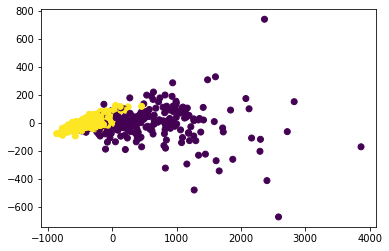

```python
from sklearn.decomposition import PCA

pca = PCA(n_components=2)

X_reduced = pca.fit_transform(X)

plt.scatter(X_reduced[:,0], X_reduced[:,1], c = y, cmap='viridis');
```

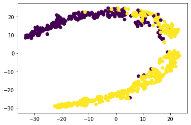

```python
from sklearn.manifold import TSNE

tsne = TSNE(n_components=2)

X_embedded = tsne.fit_transform(X)

plt.scatter(X_embedded[:,0], X_embedded[:,1], c = y, cmap='viridis');
```